# Project 2

MD. TASIN TAZWAR

2023-09-28

# Review the data table and look at the data types, distributions, values, etc.

# a. Detail any interesting patterns or issues you see.

```r
# Read the CSV file
dataset <- read.csv("C:/Users/Tasin/Desktop/demographic.csv")

# Display the first few rows of the dataset
head(dataset)
```

```
##   first_name last_name gender age    education marital_status occupation_group
## 1      Brian    Thomas   Male  39 Some College        Married       Management
## 2    Malcolm      Ryan   Male  76   HS Diploma        Married          Retired
## 3    Matthew    Brooks   Male  47  Grad Degree        Married     Professional
## 4      Tommy    Harris   Male  69  Grad Degree        Married     Professional
## 5     Ronald     Hurst   Male  52 Some College        Married      Blue Collar
## 6      Kylee  Sullivan Female  23 Some College        Married            Other
##   credit_score                         address              city state
## 1          502                 527 Ronald Loop         Pensacola    FL
## 2          379  91598 Victoria Inlet Suite 556       Panama city    FL
## 3          458              86685 Lynn Gardens       Gulf breeze    FL
## 4          621             37686 Thomas Bypass Fort walton beach    FL
## 5          349 2138 Whitehead Valleys Apt. 889         Pensacola    FL
## 6          566     51292 Wolfe Light Suite 812       Panama city    FL
##   home_build_year
## 1            1986
## 2            1971
## 3            2007
## 4            1999
## 5            1982
## 6            2015
```

```r
# Load the dplyr package
library(dplyr)
# using the glimpse function to see the dataset variable and type
glimpse(dataset)
```

```
## Rows: 10,565
## Columns: 12
## $ first_name       <chr> "Brian", "Malcolm", "Matthew", "Tommy", "Ronald", "Ky…
## $ last_name        <chr> "Thomas", "Ryan", "Brooks", "Harris", "Hurst", "Sulli…
## $ gender           <chr> "Male", "Male", "Male", "Male", "Male", "Female", "Ma…
## $ age              <int> 39, 76, 47, 69, 52, 23, 65, 46, 58, 75, 64, 55, 36, 4…
## $ education        <chr> "Some College", "HS Diploma", "Grad Degree", "Grad De…
## $ marital_status   <chr> "Married", "Married", "Married", "Married", "Married"…
## $ occupation_group <chr> "Management", "Retired", "Professional", "Professiona…
## $ credit_score     <int> 502, 379, 458, 621, 349, 566, 390, 740, 827, 540, 560…
## $ address          <chr> "527 Ronald Loop", "91598 Victoria Inlet Suite 556", …
## $ city             <chr> "Pensacola", "Panama city", "Gulf breeze", "Fort walt…
## $ state            <chr> "FL", "FL", "FL", "FL", "FL", "FL", "FL", "FL", "FL",…
## $ home_build_year  <int> 1986, 1971, 2007, 1999, 1982, 2015, 1991, 1981, 1989,…
```

# Perform any necessary data cleaning and/or transformations. This could include, but not limited to, missing data, outliers, generation of new variables, binning, etc.

```r
# Load required libraries
library(stringr)

# Check for missing values
missing_values <- sapply(dataset, function(x) sum(is.na(x)))

# Display columns with missing values
print(missing_values)
```

```
##       first_name        last_name           gender              age
##                0                0              106                0
##        education   marital_status occupation_group     credit_score
##                0             1442                0                0
##          address             city            state  home_build_year
##                0                0                0                0
```

```r
# Remove rows with missing values in any column
dataset <- dataset %>% na.omit()

# Convert columns to the correct data types
dataset$age <- as.integer(dataset$age)

# Remove rows with Age greater than 100
dataset <- dataset %>% filter(age <= 100)

# Remove leading and trailing spaces from 'city' column
dataset$city <- str_trim(dataset$city)

# Summary
summary(dataset)
```

```
##   first_name         last_name            gender               age
##  Length:9034        Length:9034        Length:9034        Min.   :19.00
##  Class :character   Class :character   Class :character   1st Qu.:37.00
##  Mode  :character   Mode  :character   Mode  :character   Median :52.00
##                                                           Mean   :51.71
##                                                           3rd Qu.:64.00
##                                                           Max.   :97.00
##   education         marital_status     occupation_group    credit_score
##  Length:9034        Length:9034        Length:9034        Min.   :300.0
##  Class :character   Class :character   Class :character   1st Qu.:441.0
##  Mode  :character   Mode  :character   Mode  :character   Median :575.0
##                                                           Mean   :574.8
##                                                           3rd Qu.:710.0
##                                                           Max.   :850.0
##    address              city              state           home_build_year
##  Length:9034        Length:9034        Length:9034        Min.   :1970
##  Class :character   Class :character   Class :character   1st Qu.:1983
##  Mode  :character   Mode  :character   Mode  :character   Median :1996
##                                                           Mean   :1996
##                                                           3rd Qu.:2010
##                                                           Max.   :2023
```

# Summarize and/or aggregate the data table values in various ways with descriptive stats, counts, etc. over the entire dataset and by various groupings.

# a. Explain each summarization step and why you did it. What patterns are you seeing?

```r
# Summarizing overall statistics
summary_stats <- dataset %>%
  summarize(
    Mean_Age = mean(age, na.rm = TRUE),
    Credit_Score = median(credit_score, na.rm = TRUE),
    Max_Age = max(age, na.rm = TRUE),
    Min_Credit_Score = min(credit_score, na.rm = TRUE),
    Count = n()
  )

# Print the summary statistics
print(summary_stats)
```

```
##   Mean_Age Credit_Score Max_Age Min_Credit_Score Count
## 1  51.7112          575      97              300  9034
```

```r
# Group the data by categorical variables like gender, and age
grouped_summary <- dataset %>%
  group_by(gender) %>%
  summarize(
    Mean_Age = mean(age, na.rm = TRUE),
    Median_Credit_Score = median(credit_score, na.rm = TRUE),
    Count = n()
  )

# Print the Grouped summary
print(grouped_summary)
```

```
## # A tibble: 2 × 4
##   gender Mean_Age Median_Credit_Score Count
##   <chr>     <dbl>               <dbl> <int>
## 1 Female     46.9                578.  1780
## 2 Male       52.9                574   7254
```

Through ‘group_by’ method, it is possible to group the data of the categorical variables. This helps to compare statistics among different groups like mean age, median cresti score, etc.

```r
# Count each unique value on 'gender' column
gender_counts <- dataset %>%
  count(gender)

# Print count
print(gender_counts)
```

```
##   gender    n
## 1 Female 1780
## 2   Male 7254
```

The number of unique records in each column can be found through “count()” method

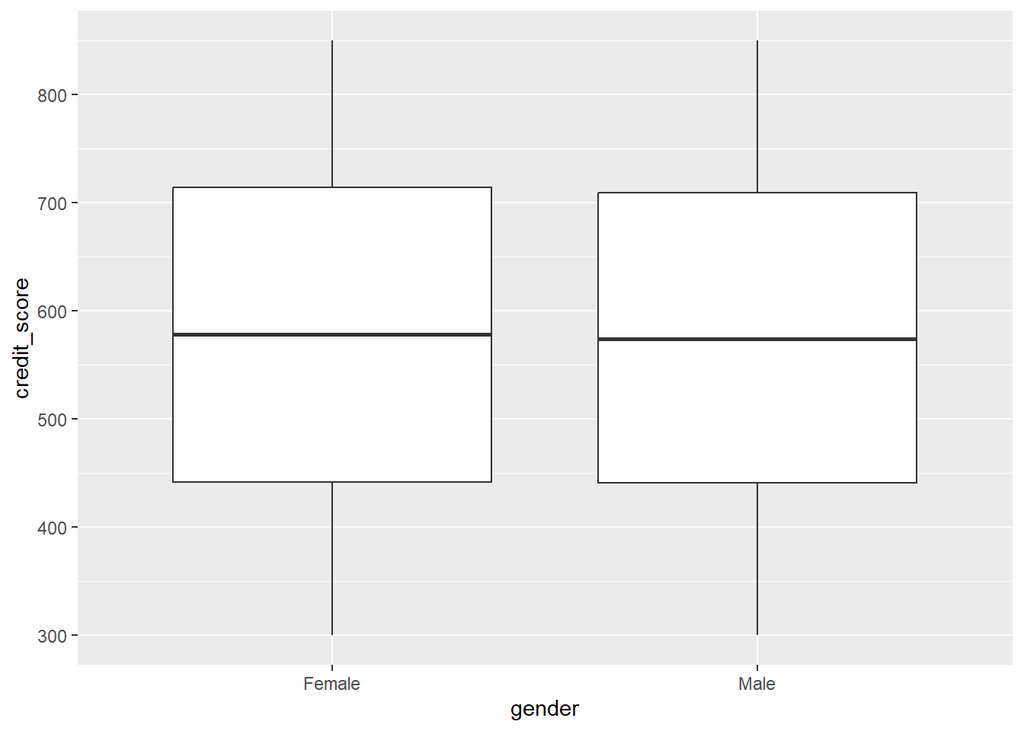

```r
# Data Visualization

# Creating box plots to visualize the pattern and relationship between the 'gender' and 'credit score'

library(ggplot2)
ggplot(dataset, aes(x = gender, y = credit_score)) +
  geom_boxplot()
```

Here, I have visualized the distribution of credit score by gender to identify the differences. Interestingly, the credit score of both Female and Male are kind of similar.

# Leveraging the analyses in steps 1-3, create at least four different plots over variables you finding interesting to include univariate and multivariate (covariation) analyses. Make sure the plots are customized appropriately with labels, titles, colors, and themes.

# a. Explain each visual and why you chose to use this particular plot.

# b. Interpret what each plot is showing and what this could say about the demographics provided (e.g. trends such as age distribution or gender distribution).

# c. What overall patterns and/or trends do you see?

# d. How do the visuals add to your previous review and summarization?

# e. Do the visuals you provided tell a bigger story (when looked at together), i.e. do the individual plots coalesce into a larger narrative about the demographic data?

Plot 1: Age Distribution (Histogram)

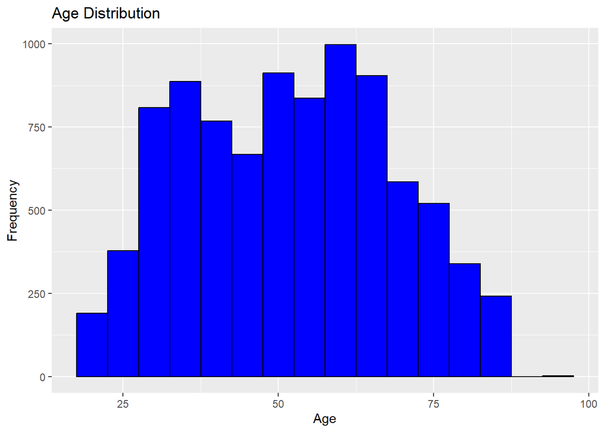

```r
# Create a histogram of Age distribution
library(ggplot2)
age_histogram <- ggplot(dataset, aes(x = age)) +
  geom_histogram(binwidth = 5, fill = "blue", color = "black") +
  labs(title = "Age Distribution", x = "Age", y = "Frequency")

print(age_histogram)
```

Plot 2: Credit Score by Gender (Box Plot)

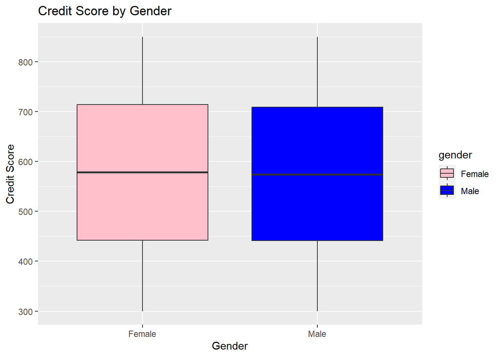

```r
# Create a box plot of Credit Score by Gender
credit_score_boxplot <- ggplot(dataset, aes(x = gender, y = credit_score, fill = gender)) +
  geom_boxplot() +
  labs(title = "Credit Score by Gender", x = "Gender", y = "Credit Score") +
  scale_fill_manual(values = c("Male" = "blue", "Female" = "pink"))

print(credit_score_boxplot)
```

Type: Bivariate (Covariation) Explanation: This box plot is showing the distribution of credit score within each gender category, that indicates to compare credit score between males and females. Interpretation: We can identify differences or similarities in credit score between genders. Interestingly, there are high similarities. Overall Patterns/Trends: Males and females have kind of similar type of credit score distributions.

Plot 3: Gender Distribution (Bar Chart)

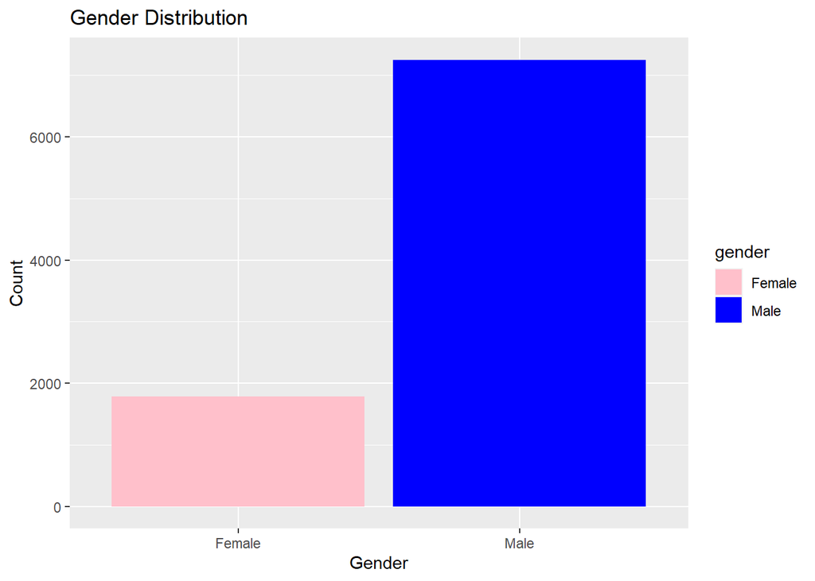

```r
# Create a bar chart of Gender distribution
gender_bar_chart <- ggplot(dataset, aes(x = gender, fill = gender)) +
  geom_bar() +
  labs(title = "Gender Distribution", x = "Gender", y = "Count") +
  scale_fill_manual(values = c("Male" = "blue", "Female" = "pink"))

print(gender_bar_chart)
```

Type: Univariate Explanation: This bar chart is showing the distribution of genders in the dataset. Interpretation: We can observe the proportion of males and females in the dataset. Overall Patterns/Trends: The number of male is significantly higher than female.

Plot 4: Age vs Credit Score (Scatter plot)

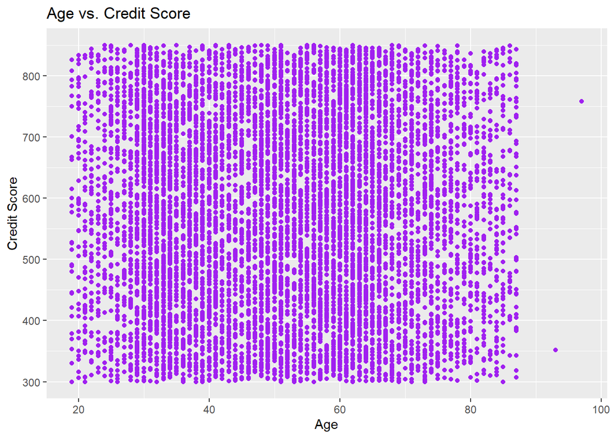

```r
# Create a scatter plot of Age vs. Credit Score
# Create a scatter plot of Age vs. Credit Score
age_credit_scatter <- ggplot(dataset, aes(x = age, y = credit_score)) +
  geom_point(color = "purple") +
  labs(title = "Age vs. Credit Score", x = "Age", y = "Credit Score")

print(age_credit_scatter)
```

Summary: These visualizations shows the visual layer to the previous summary statistics that indicates more detailed understanding of the dataset. These plots can tell the bigger story about the demographic data. It is seen that there is a gender imbalance in the datasets as well as insigths of age distribution, gender representation, credit score, and the correlation between variables.

# Summarize your interpretation of the overall results of your demographic analysis, discussing any interesting insights or trends you discovered. Posit what could be done with your analysis results—could this demographic data lead to actionable insights?

```r
summary(dataset)
```

```
##   first_name         last_name            gender               age
##  Length:9034        Length:9034        Length:9034        Min.   :19.00
##  Class :character   Class :character   Class :character   1st Qu.:37.00
##  Mode  :character   Mode  :character   Mode  :character   Median :52.00
##                                                           Mean   :51.71
##                                                           3rd Qu.:64.00
##                                                           Max.   :97.00
##   education         marital_status     occupation_group    credit_score
##  Length:9034        Length:9034        Length:9034        Min.   :300.0
##  Class :character   Class :character   Class :character   1st Qu.:441.0
##  Mode  :character   Mode  :character   Mode  :character   Median :575.0
##                                                           Mean   :574.8
##                                                           3rd Qu.:710.0
##                                                           Max.   :850.0
##    address              city              state           home_build_year
##  Length:9034        Length:9034        Length:9034        Min.   :1970
##  Class :character   Class :character   Class :character   1st Qu.:1983
##  Mode  :character   Mode  :character   Mode  :character   Median :1996
##                                                           Mean   :1996
##                                                           3rd Qu.:2010
##                                                           Max.   :2023
```

Credit Score: The credit scores are sort of similar of men and women. This indicates the fairness and equity in terms of credit score

Gender Representation: The dataset shows a gender imbalance, with more individuals identified as male than female. This imbalance may have implications for gender related analysis and decision making that should consider gender representation.

Age vs Credit Score correlation: The scatter plot shows the relation between age and credit score. All of the age grouped people have a credit scores are in between in a certain number.

Actionable Insights: Since most of the people in this dataset are middle aged, then some marketing strategies can be used for this aged group. Gender equity initiatives can be taken by the authority since there are an imbalance between male and female in terms of amount / number of people. People’s credit score is available but income is absent here that may plays a vital role if any financial decision making policy would be implemented. Finally, the demographic analysis provides the valuable insights in the dataset. Though it does not provide all the answers, but it plays an important role for any decision making policy.